# Spatial & Temporal structure

Iliana Vasiliki Ntinou

6/2/2021

## Simulation

1. Simulate a 100-observation autocorrelated timeseries with `arima.sim`, with a first order autoregressive coefficient of 0.5. Also make a time vector of `1:100`

```r
#Load libraries
library(nlme)
library(tidyverse)
library(lmtest)
library(broom.mixed)
```

```r
ts.sim<-arima.sim(list(order=c(1,0,0)#specifying that this is an AR1 model 1st order
                       , ar=0.5),#autoregressive coefficient
                  n=100) #number of obs
time <- c(1:100)
```

2. Plot the data.

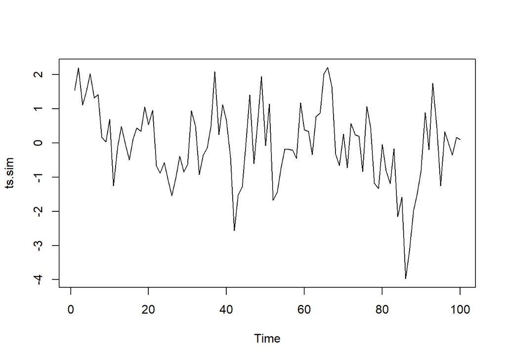

```r
ts.plot(ts.sim)
```

3. Regress the timeseries against time with an OLS model. Does the model appear to be statistically significant?

```r
lm.0 <- lm(ts.sim~time(ts.sim))
lm.0
```

```
##
## Call:
## lm(formula = ts.sim ~ time(ts.sim))
##
## Coefficients:
##  (Intercept)  time(ts.sim)
##      0.52694      -0.01118
```

```r
anova(lm.0)
```

```
## Analysis of Variance Table
##
## Response: ts.sim
##              Df  Sum Sq Mean Sq F value   Pr(>F)
## time(ts.sim)  1  10.411 10.4107  8.3033 0.004862 **
## Residuals    98 122.872  1.2538
## ---
## Signif. codes:  0 '***' 0.001 '**' 0.01 '*' 0.05 '.' 0.1 ' ' 1
```

4. Plot the model diagnostics, including an `acf` and `pacf` of the residuals.

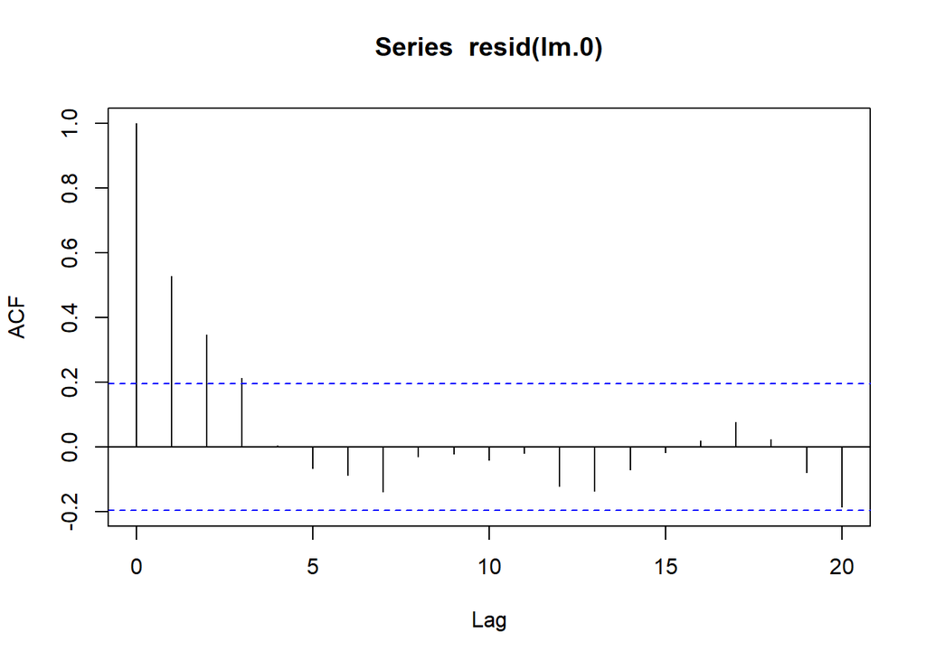

```r
acf(resid(lm.0))
```

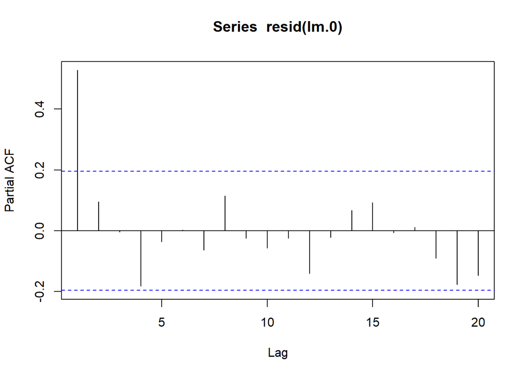

```r
pacf(resid(lm.0))
```

5. Use the Durbin-Watson test to test the residuals for autocorrelation.

```r
dwtest(lm.0)
```

```
##
##  Durbin-Watson test
##
## data:  lm.0
## DW = 0.93235, p-value = 1.93e-08
## alternative hypothesis: true autocorrelation is greater than 0
```

6. Fit a gls with an appropriate correlation structure. Is this a better model? How have the p-value and effect size changed?

```r
gls.0 <- gls(ts.sim~time(ts.sim))
summary(gls.0)
```

```
## Generalized least squares fit by REML
##   Model: ts.sim ~ time(ts.sim)
##   Data: NULL
##        AIC      BIC    logLik
##   322.2129 329.9678 -158.1064
##
## Coefficients:
##                   Value  Std.Error   t-value p-value
## (Intercept)   0.5269437 0.22563625  2.335368  0.0216
## time(ts.sim) -0.0111777 0.00387905 -2.881547  0.0049
##
##  Correlation:
##              (Intr)
## time(ts.sim) -0.868
##
## Standardized residuals:
##          Min           Q1          Med           Q3          Max
## -3.161815195 -0.663392463  0.004655545  0.673488033  2.159751756
##
## Residual standard error: 1.11973
## Degrees of freedom: 100 total; 98 residual
```

```r
gls.00 <- gls(ts.sim~time(ts.sim), corr=corAR1())
summary(gls.00)
```

```
## Generalized least squares fit by REML
##   Model: ts.sim ~ time(ts.sim)
##   Data: NULL
##        AIC      BIC    logLik
##   289.0371 299.3769 -140.5185
##
## Correlation Structure: AR(1)
##  Formula: ~1
##  Parameter estimate(s):
##      Phi
## 0.560632
##
## Coefficients:
##                   Value Std.Error  t-value p-value
## (Intercept)   0.5607783 0.4218949  1.32919  0.1869
## time(ts.sim) -0.0114239 0.0072074 -1.58503  0.1162
##
##  Correlation:
##              (Intr)
## time(ts.sim) -0.863
##
## Standardized residuals:
##         Min          Q1         Med          Q3         Max
## -3.09929897 -0.65776760 -0.01820141  0.64549452  2.09416547
##
## Residual standard error: 1.146402
## Degrees of freedom: 100 total; 98 residual
```

```r
anova(gls.0, gls.00)
```

```
##        Model df      AIC      BIC    logLik   Test  L.Ratio p-value
## gls.0      1  3 322.2129 329.9678 -158.1064
## gls.00     2  4 289.0371 299.3769 -140.5185 1 vs 2 35.17577  <.0001
```

7. Repeat the above 1000 times and find how autocorrelation affects the distribution of the p-value and the effect size.

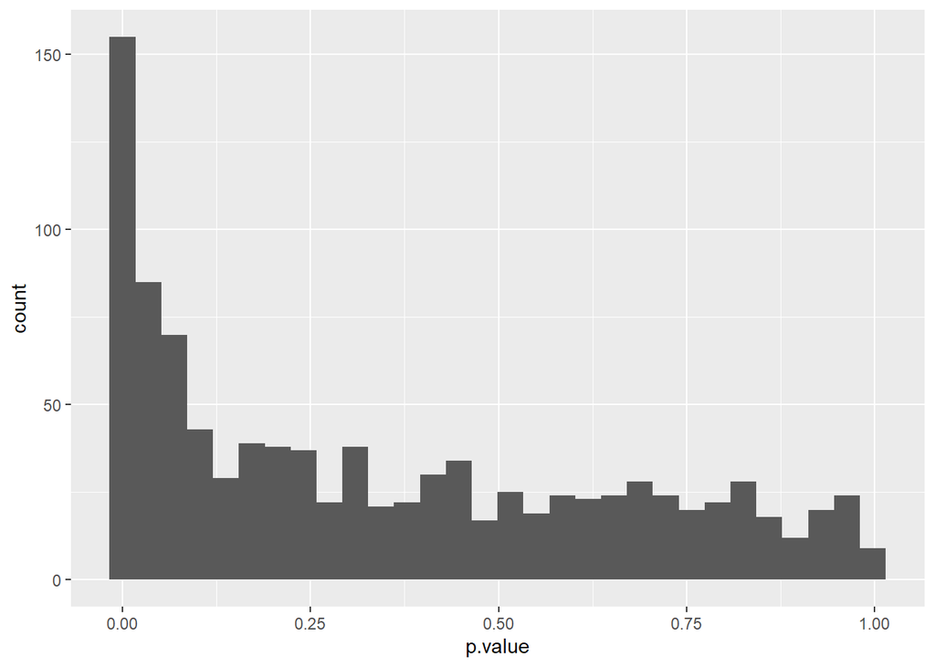

```r
rerun(1000, {ts.sim<-arima.sim(list(order=c(1,0,0), ar=0.5), n=100)
time <- c(1:100)
lm.0 <- lm(ts.sim~time(ts.sim))})%>%
map_dfr(glance) %>%
  ggplot(aes(x = p.value)) +
  geom_histogram()
```

## Real data

```r
data(LakeHuron)
summary(LakeHuron)
```

```
##    Min. 1st Qu.  Median    Mean 3rd Qu.    Max.
##   576.0   578.1   579.1   579.0   579.9   581.9
```

2. Plot the data.

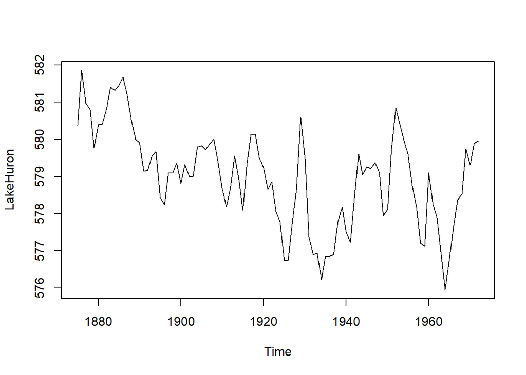

```r
plot(LakeHuron)
```

3. Regress the LakeHuron lake level against year using a linear model. Is there a significant trend?

```r
mod1<-lm(LakeHuron~time(LakeHuron))
summary(mod1)
```

```
##
## Call:
## lm(formula = LakeHuron ~ time(LakeHuron))
##
## Residuals:
##      Min       1Q   Median       3Q      Max
## -2.50997 -0.72726  0.00083  0.74402  2.53565
##
## Coefficients:
##                   Estimate Std. Error t value Pr(>|t|)
## (Intercept)     625.554918   7.764293  80.568  < 2e-16 ***
## time(LakeHuron)  -0.024201   0.004036  -5.996 3.55e-08 ***
## ---
## Signif. codes:  0 '***' 0.001 '**' 0.01 '*' 0.05 '.' 0.1 ' ' 1
##
## Residual standard error: 1.13 on 96 degrees of freedom
## Multiple R-squared:  0.2725, Adjusted R-squared:  0.2649
## F-statistic: 35.95 on 1 and 96 DF,  p-value: 3.545e-08
```

4. Plot the autocorrelation and partial autocorrelation functions for the residuals from this regression. Interpret them.

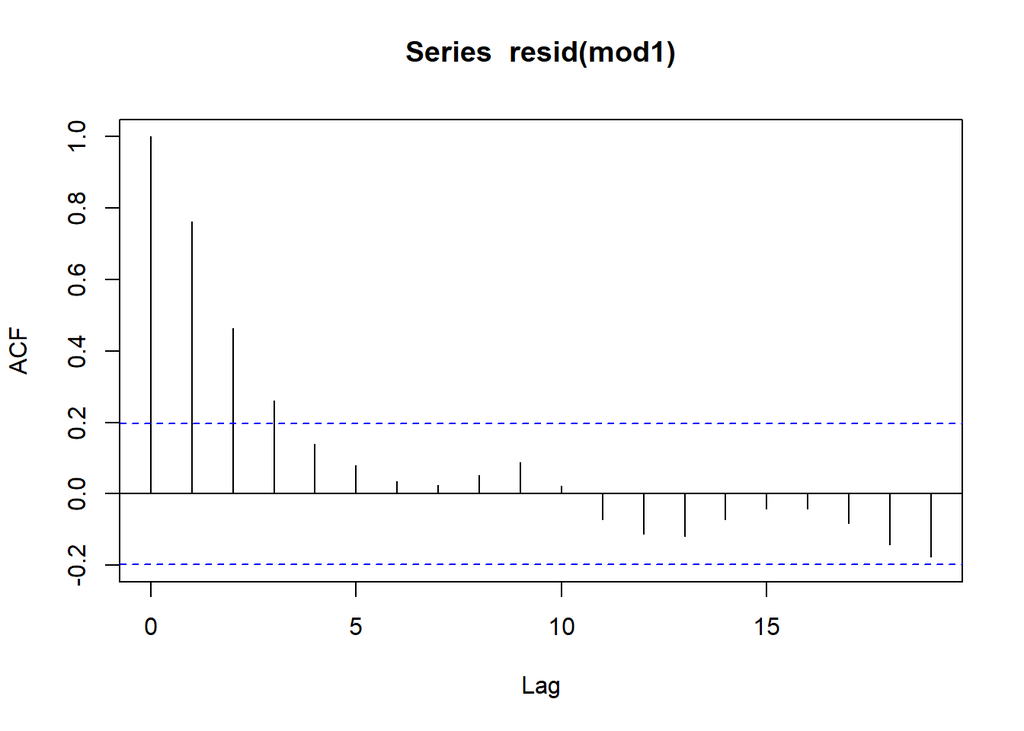

```r
acf(resid(mod1))
```

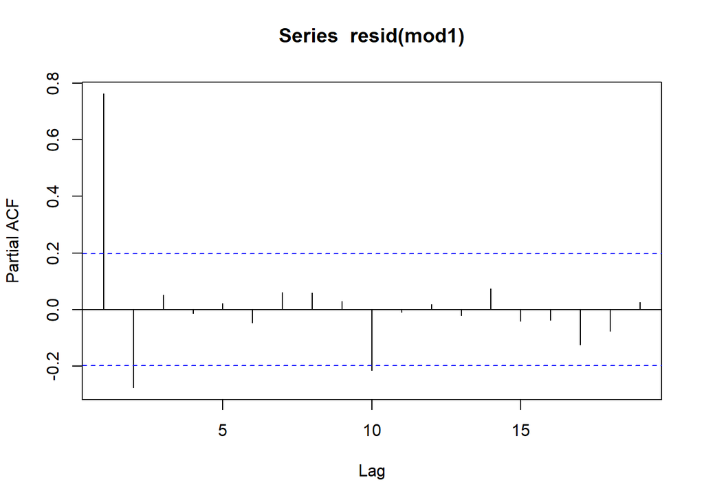

```r
pacf(resid(mod1))
```

5. Fit an autoregressive models to the residuals. Compare the results with your interpretation of the PACF plot.

```r
year<-time(LakeHuron)
fit.gls<-gls(LakeHuron~year)
summary(fit.gls)
```

```
## Generalized least squares fit by REML
##   Model: LakeHuron ~ year
##   Data: NULL
##        AIC      BIC    logLik
##   317.8056 325.4986 -155.9028
##
## Coefficients:
##                Value Std.Error  t-value p-value
## (Intercept) 625.5549  7.764293 80.56817       0
## year         -0.0242  0.004036 -5.99615       0
##
##  Correlation:
##      (Intr)
## year -1
##
## Standardized residuals:
##           Min            Q1           Med            Q3           Max
## -2.2206487930 -0.6434298311  0.0007333699  0.6582616816  2.2433687340
##
## Residual standard error: 1.130287
## Degrees of freedom: 98 total; 96 residual
```

6. Fit a gls model using a corAR1 correlation structure. Test if the correlation structure is necessary. Is the trend significant?

```r
fit2.gls<-gls(LakeHuron~year, corr=corAR1())
summary(fit2.gls)
```

```
## Generalized least squares fit by REML
##   Model: LakeHuron ~ year
##   Data: NULL
##        AIC      BIC    logLik
##   225.8304 236.0878 -108.9152
##
## Correlation Structure: AR(1)
##  Formula: ~1
##  Parameter estimate(s):
##       Phi
## 0.8247674
##
## Coefficients:
##                Value Std.Error   t-value p-value
## (Intercept) 616.4887 24.362632 25.304683  0.0000
## year         -0.0194  0.012664 -1.534616  0.1282
##
##  Correlation:
##      (Intr)
## year -1
##
## Standardized residuals:
##         Min          Q1         Med          Q3         Max
## -2.11192554 -0.57663992 -0.05772191  0.53782186  1.82271164
##
## Residual standard error: 1.260554
## Degrees of freedom: 98 total; 96 residual
```

```r
anova(fit.gls,fit2.gls)
```

```
##          Model df      AIC      BIC    logLik   Test  L.Ratio p-value
## fit.gls      1  3 317.8056 325.4986 -155.9028
## fit2.gls     2  4 225.8304 236.0878 -108.9152 1 vs 2 93.97515  <.0001
```

7. Fit a gls model using a corARMA correlation structure with two AR terms. Is this model an improvement?

```r
fit3.gls <- gls(LakeHuron~year, corr=corARMA(p=2,q=0))
summary(fit3.gls)
```

```
## Generalized least squares fit by REML
##   Model: LakeHuron ~ year
##   Data: NULL
##       AIC      BIC   logLik
##   221.028 233.8497 -105.514
##
## Correlation Structure: ARMA(2,0)
##  Formula: ~1
##  Parameter estimate(s):
##       Phi1       Phi2
##  1.0203418 -0.2741249
##
## Coefficients:
##                Value Std.Error  t-value p-value
## (Intercept) 619.6442 17.491090 35.42628  0.0000
## year         -0.0211  0.009092 -2.32216  0.0223
##
##  Correlation:
##      (Intr)
## year -1
##
## Standardized residuals:
##         Min          Q1         Med          Q3         Max
## -2.16624672 -0.57959971  0.01070681  0.61705337  2.03975934
##
## Residual standard error: 1.18641
## Degrees of freedom: 98 total; 96 residual
```

```r
anova(fit.gls,fit2.gls, fit3.gls)
```

```
##          Model df      AIC      BIC    logLik   Test  L.Ratio p-value
## fit.gls      1  3 317.8056 325.4986 -155.9028
## fit2.gls     2  4 225.8304 236.0878 -108.9152 1 vs 2 93.97515  <.0001
## fit3.gls     3  5 221.0280 233.8497 -105.5140 2 vs 3  6.80244  0.0091
```